# PracaDomowa03

Grzegorz Zbrzeżny & Tomasz Siudalski

13 11 2021

# Eksperyment 1

W pierwszym eksperymencie wzięliśmy dane z sondażu parlamentarnego przeprowadzonego w dniach 22-23 października bieżącego roku. Na ich podstawie stworzyliśmy dwa wykresy, jeden słupkowy z jednolitym kolorem, a drugi to trójwymiarowy, kołowy wykres z jaskrawą legendą.

## Wykres kołowy

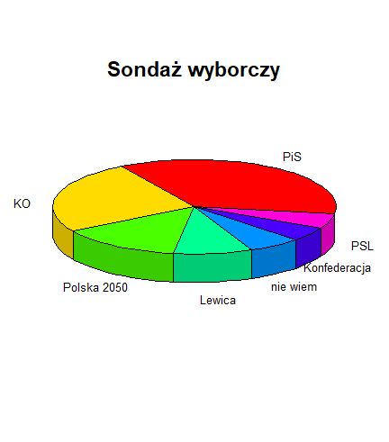

## Wykres słupkowy

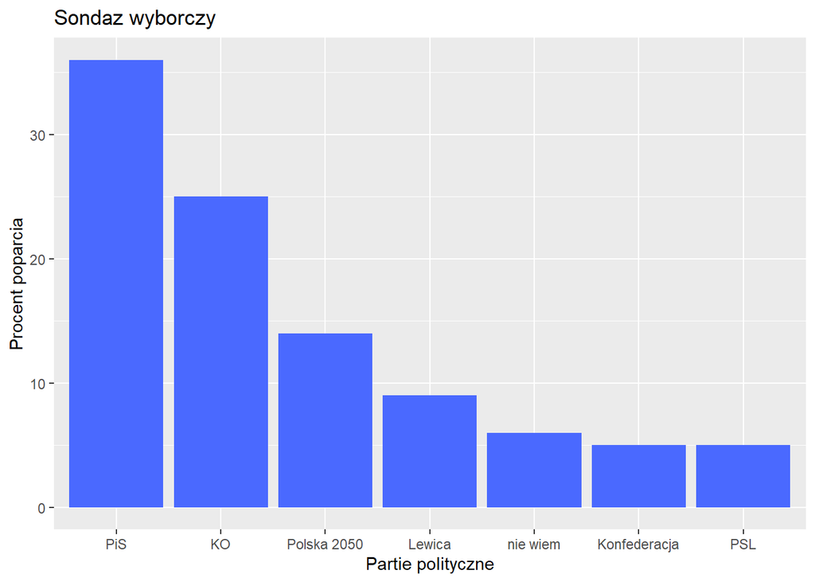

Chcieliśmy sprawdzić, czy cechy nadane wykresowi kołowemu faktycznie ograniczą jego czytelność. W tym celu przeprowadziliśmy ankietę, w której udział wzięło piętnaście osób. Zadaliśmy im po dwa pytania. Pierwsze polegało na odczytaniu wyników z wyżej wstawionych wykresów, natomiast drugie na zaznaczeniu, który z tych wykresów uważają za bardziej czytelny.

## Ankieta - wyniki pytania pierwszego

Poniższa ramka danych przedstawia odpowiedzi na pytanie pierwsze odnośnie wykresu kołowego

```
##    PiS KO Polska.2050 Lewica Konfederacja PSL nie.wiem
## 1   33 20          10     10            4   3        4
## 2   34 21          14     10            3   3        4
## 3   35 23          15     10            3   4        5
## 4   35 25          15     10            4   4        6
## 5   35 25          15     10            4   5        6
## 6   35 25          15     10            4   3        6
## 7   35 25          15     11            5   4        6
## 8   37 25          15     11            5   5        6
## 9   39 25          15     11            5   5        6
## 10  39 25          15     15            5   5        7
## 11  40 25          15     17            6   5        7
## 12  40 25          15      8            6   5        7
## 13  40 25          15      8            7   7        8
## 14  40 26          18      9            7   6        9
## 15  60 28          18      9            8   3       10
```

Wyniki odnosnie wykresu słupkowego przedstawiono w tej ramce danych

```
##    PiS KO Polska.2050 Lewica Konfederacja PSL nie.wiem
## 1   36 24          14      8            6   7       11
## 2   36 25          14      8            7   5        6
## 3   36 25          14      8            5   5        6
## 4   36 25          14      9            5   5        6
## 5   36 25          14      9            5   5        6
## 6   36 25          14      9            5   5        6
## 7   36 25          14      9            5   5        6
## 8   36 25          14      9            5   5        6
## 9   36 25          14      9            5   5        6
## 10  36 25          14      9            5   5        6
## 11  36 25          14      9            5   5        6
## 12  36 25          14      9            5   5        6
## 13  37 25          14      9            5   5        6
## 14  37 25          14      9            5   5        6
## 15  37 25          14      9            5   5        7
```

Aby móc w jakiś konkretny porównać wyniki, postanowiliśmy obliczyć ich średnią dla danych partii politycznych, a nastepnie przedstawić w skali procentowej o ile różnią się one do faktycznych danych. W taki właśnie sposób powstał poniższy wykres

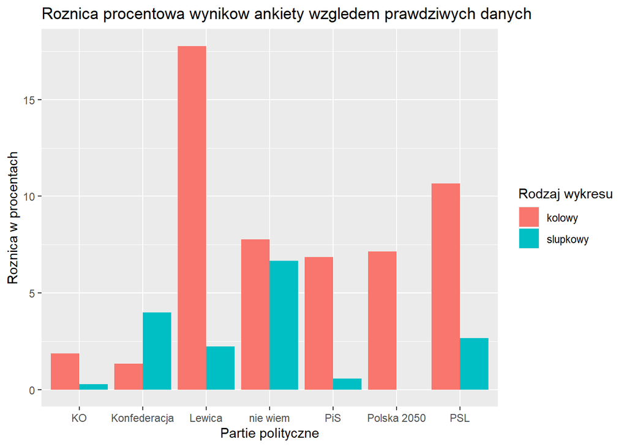

Jak widać ewidentnie bardziej dokładne wyniki otrzymaliśmy z wykresu słupkowego

## Ankieta - wyniki pytania drugiego

Wyniki pytania o to, który wykres jest bardziej czytelny, przedstawia poniższy wykres

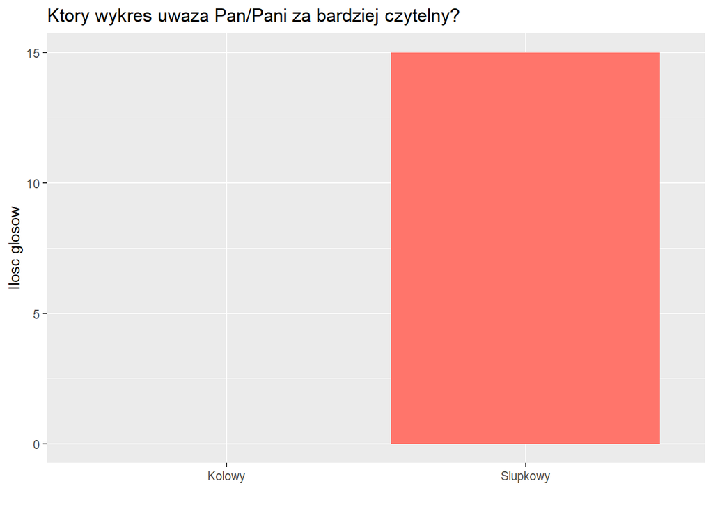

Wykres słupkowy został jednogłośnie uznany za bardziej czytelny. Oznacza to, że faktycznie przedstawianie danych na wykresach kołowych, 3D, czy z jaskrawymi barwami w legendzie nie wpływa pozytywnie na czytelność.

# Eksperyment 2

W drugim eksperymencie skorzystaliśmy z raportu dotyczącego m.in. stresu w pracy „Poznaj swoje prawa w pracy – wsparcie kompetencyjne działaczy OPZZ oraz pracowników”. Wybraliśmy dane dotyczące czynników stresogennych w miejscu pracy w różnych grupach wiekowych i użyliśmy ich do stworzenia dwóch wykresów słupkowych: trój- dwuwymiarowego. Naszym celem było sprawdzenie czy prawdą jest że wykresy 3D są cięższe w odczytaniu niż wykresy 2D. Aby to sprawdzić stworzyliśmy druga ankietę, która również polegała na odczytywaniu danych z wykresu, pierwsze 4 pytania dotyczyły pierwszego wykresu a 4 kolejne drugiego. Na końcu pytaliśmy także ankietowanych z którego wykresu łatwiej im było odczytywać dane, który uważają za bardziej przejrzysty.

## Wykres słupkowy 3d

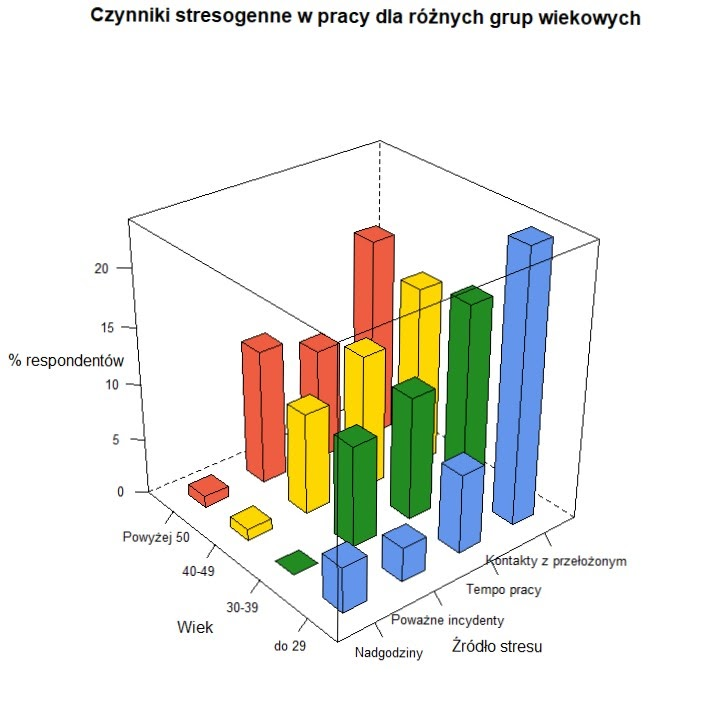

## Wykres słupkowy 2d

[figure not shown]

## Wyniki ankiety

Pytania:

- Odczytaj z wykresu jaka część osób z grupy wiekowej do 29 lat odczuwa stres z powodu nadgodzin.
- Odczytaj z wykresu jaka część osób z grupy wiekowej 30-39 lat odczuwa stres z powodu kontaktu z przełożonym.
- Odczytaj z wykresu jaka część osób z grupy wiekowej 40-49 lat odczuwa stres z powodu tempa pracy.
- Odczytaj z wykresu jaka część osób z grupy wiekowej powyżej 50 lat odczuwa stres z powodu poważnych incydentów.
- Odczytaj z wykresu jaka część osób z grupy wiekowej do 29 lat odczuwa stres z powodu kontaktu z przełożonym.
- Odczytaj z wykresu jaka część osób z grupy wiekowej 30-39 lat odczuwa stres z powodu tempa pracy.
- Odczytaj z wykresu jaka część osób z grupy wiekowej 40-49 lat odczuwa stres z powodu poważnych incydentów.
- Odczytaj z wykresu jaka część osób z grupy wiekowej powyżej 50 lat odczuwa stres z powodu nadgodzin.

Odpowiedzi na pierwsze 8 pytań polegających na odczytywaniu wartości z wykresu, w postaci ramki danych:

```
##    Pytanie 1 Pytanie 2 Pytanie 3 Pytanie 4 Pytanie 5 Pytanie 6 Pytanie 7
## 1          5        20      15.0      15.0        24        11       8.0
## 2          5        20      15.0      14.0        27        12       7.0
## 3          5        20      15.0      15.0        23        12       8.0
## 4          6        17      15.0      12.0        24        11       9.0
## 5          7        17      10.0      14.0        24        12       7.0
## 6          5        15      10.0      10.0        23        12       9.0
## 7          5        15      11.0      12.0        23        12       8.0
## 8          5        15      12.0      12.0        24        11       9.0
## 9          5        15      13.0      15.0        23        14       8.0
## 10         5        18      15.0      14.0        24        11       8.0
## 11         5        18      15.0      15.0        23        11       8.5
## 12         5        20      15.0      15.0        23        11       9.0
## 13         7        15      12.0      13.0        23        12       8.0
## 14         5        20      12.5      12.5        24        11       9.0
```

[output cut: 17 more lines]

W celu porównania obu wykresów zsumowaliśmy błędy bezwzględne dla każdego z pytań i wyniki przedstawiliśmy na poniższym wykresie.

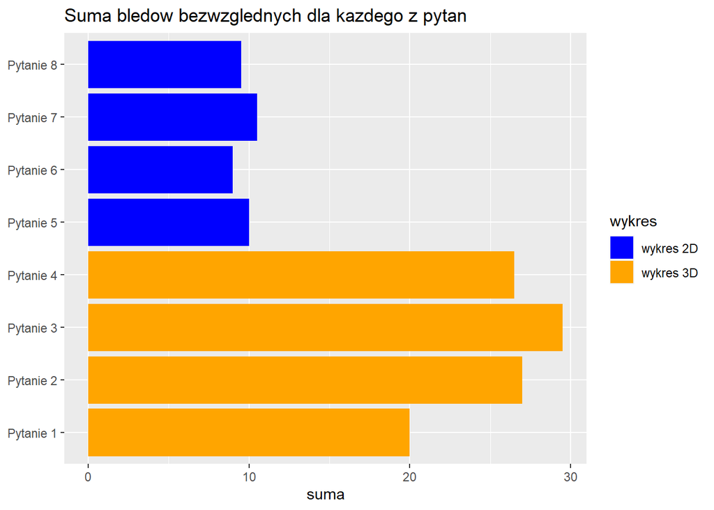

Jak można zauważyć dla wykresu 2D błędy pomiaru są zdecydowanie mniejsze, z czego wynika że ankietowani mogli dokładniej określić szukaną przez nich wartość.

Na poniższym wykresie pokazaliśmy wyniki ostatniego pytania.

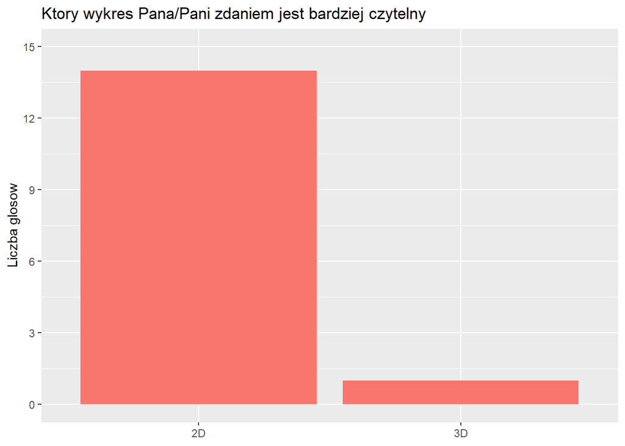

Zdecydowana większość użytkowników uważa wykres 2D za łatwiejszy do odczytania niż 3D. Wynika z tego, że wykresy trójwymiarowe, pomimo tego że są bardziej skomplikowane, nowocześniejsze i wielu może podobać się ich design, to gorzej przekazują informacje i są trudniejsze do odczytania.